# SA_Assignment

Vaibhav Dixit

15/09/2021

## Data loading, validating the toatl Score and removing the null values are done below:

```r
setwd('C:/Users/denti/Downloads/')
library(xlsx)
ST_SA <- read.xlsx("SA_Assignment.xlsx", sheetName = "Sheet1")
col1 <- c('READ','WRITE','MATH')
ST_SA$Total_Cal <- apply(ST_SA[,col1],1,sum)

ST_SA$Total_Cmp <- ifelse(ST_SA$TOTAL==ST_SA$Total_Cal,"Yes","No")

ST_SA$Total_fin <- ifelse(ST_SA$TOTAL==ST_SA$Total_Cal,ST_SA$TOTAL,ST_SA$Total_Cal)

ST_SA$Total_Cmp <- NULL
ST_SA$Total_Cal <- NULL
ST_SA[is.na(ST_SA)] = 0
```

##Draw a histogram for the TOTAL score (you have to define appropriate class intervals) and comment on the distribution of the TOTAL score.

##Observation: The below graph is : ## left skewed which means mean is less than the median ## There are few values that are pushing the mean towards the left i.e there is a big difference between min and max vallue ## Majority of the candidates have the Total score between 40 to 80 ## No one from the sample scored more than 90 ## As the histogram is close to normal distribution. We can say that there will not be much difference between the count of candidates above and below the mean value

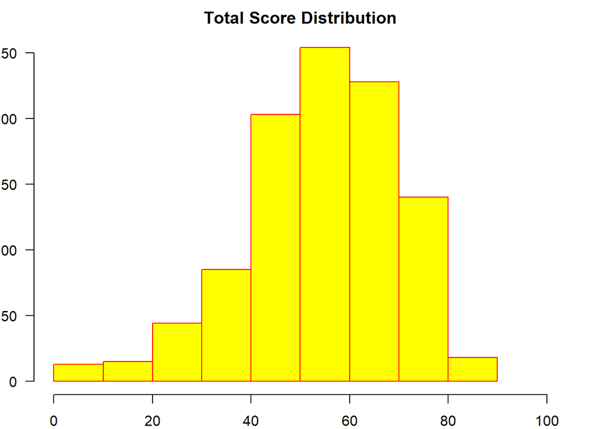

```r
par(mar = rep(2, 4))
hist(ST_SA$Total_fin,
     main="Total Score Distribution",
     xlab="Score Range",
     border="red",
     col="yellow",
     xlim=c(0,100),
     las=1,
     breaks=10)
```

```r
range(ST_SA$Total_fi)
```

```
## [1]  0 88
```

#Create a new variable called “PERFORMANCE”. If the score is above the sample average, label the PERFORMANCE as “HIGH”, otherwise, “LOW”. Using the new variable “PERFORMANCE” and GENDER, comment on the relative performance of Male and Female learners

## After adding the performance column it can be seen that

## %age wise more males scored above average in total male population when compatred to the female population in total female population

## The top scorer is a Female

## The mean age of the candidates who performed above average in Females is higher than that of the males

## when we see score above 80 young age males only are able to achieve that whereas in females mid-age group till 40 are able to score high

```r
ST_SA$Total_Perf <- ifelse(ST_SA$Total_fin > mean(ST_SA$Total_fin),"HIGH","LOW")

library(dplyr)
# Male performance above average in male population
nrow(filter(ST_SA,ST_SA$Gender == "T",ST_SA$Total_Perf == "HIGH"))/nrow(ST_SA[ST_SA$Gender == "T",])
```

```
## [1] 0.5981873
```

```r
# Female performance above average in female population
nrow(filter(ST_SA,ST_SA$Gender == "F",ST_SA$Total_Perf == "HIGH"))/nrow(ST_SA[ST_SA$Gender == "F",])
```

```
## [1] 0.5276532
```

```r
Gender_Female <- filter(ST_SA,ST_SA$Gender == "F",ST_SA$Total_Perf == "HIGH")
Gender_Male <- filter(ST_SA,ST_SA$Gender == "T",ST_SA$Total_Perf == "HIGH")
## Highest score by a Female
max(Gender_Female$Total_fin)
```

```
## [1] 88
```

```r
## Highest score by a male
max(Gender_Male$Total_fin)
```

```
## [1] 86
```

```r
## Male age summary who performed above average
summary(Gender_Male$AGE)
```

```
##    Min. 1st Qu.  Median    Mean 3rd Qu.    Max.
##   13.00   19.00   23.00   25.26   29.00   55.00
```

```r
## Female age summary who performed above average
summary(Gender_Female$AGE)
```

```
##    Min. 1st Qu.  Median    Mean 3rd Qu.    Max.
##   12.00   21.00   27.00   27.29   32.00   68.00
```

```r
## Above 80 marks summary Male
Male_80 <- filter(Gender_Male,Gender_Male$Total_fin > 80)
summary(Male_80$AGE)
```

```
##    Min. 1st Qu.  Median    Mean 3rd Qu.    Max.
##   14.00   17.00   18.50   19.67   23.75   25.00
```

```r
Female_80 <- filter(Gender_Female,Gender_Female$Total_fin > 80)
## Above 80 marks summary Female
summary(Female_80$AGE)
```

```
##    Min. 1st Qu.  Median    Mean 3rd Qu.    Max.
##   14.00   22.00   28.00   28.17   32.75   40.00
```

##Using the sample that you have just selected, calculate a 95% two-sided confidence interval for the following. #A. Mean of TOTAL Score #B. Mean of INCOME #C. Proportion of “HIGH” performers among Male learners #D. Proportion of “HIGH” performers among Female Learners

```r
## Confidence interval for the mean of total score
## Xbar is Mean of Total Score
mn_ts <- mean(ST_SA$Total_fin)
mn_ts
```

```
## [1] 54.89916
```

```r
## Mean of Standard deviation
sd_ts <- sd(ST_SA$Total_fin)
sd_ts
```

```
## [1] 15.59356
```

```r
## Zscore of Z0.95
Zs_alph <- (-qnorm((1-0.95)/2))
Zs_alph
```

```
## [1] 1.959964
```

```r
## Z(1-alpha)*(standard deviation)/sqrt(n) where n =16
abc <- Zs_alph*(sd_ts/sqrt(16))
abc
```

```
## [1] 7.640705
```

```r
## confidence interval mean of the total score is
## 54.89916 +- 7.640705
aaa=mn_ts + abc
aaa
```

```
## [1] 62.53987
```

```r
bbb=mn_ts - abc
bbb
```

```
## [1] 47.25845
```

```r
## Interval is
## P(47.25845 <= μ <= 62.53987) = 0.95
```

```r
## Confidence interval for the mean of Income
mn_inc <- mean(ST_SA$INCOME)
mn_inc
```

```
## [1] 5763.195
```

```r
sd_inc <- sd(ST_SA$INCOME)
sd_inc
```

```
## [1] 4520.737
```

```r
## Zscore of Z0.95
Zs_alphinc <- (-qnorm((1-0.95)/2))
Zs_alphinc
```

```
## [1] 1.959964
```

```r
## Z(1-alpha)*(standard deviation)/sqrt(n) where n =16
abc_i <- Zs_alphinc*(sd_inc/sqrt(16))
abc_i
```

```
## [1] 2215.12
```

```r
## confidence interval mean of the income is
## 5763.195 +- 2215.120
aa_i=mn_inc + abc_i
aa_i
```

```
## [1] 7978.315
```

```r
bb_i=mn_inc - abc_i
bb_i
```

```
## [1] 3548.075
```

```r
## Interval is
## P(3548.074 <= μ <= 7978.315) = 0.95
```

```r
## Proportion of “HIGH” performers among Male learners
## Sol: Here n is 331 (Total number of males in the samples)
t_mn <- nrow(filter(ST_SA,ST_SA$Gender=="T"))
t_mn
```

```
## [1] 331
```

```r
## P will be
PM_bar <- nrow(filter(ST_SA,ST_SA$Gender=="T",ST_SA$Total_Perf=="HIGH"))/nrow(filter(ST_SA,ST_SA$Gender=="T"))
PM_bar
```

```
## [1] 0.5981873
```

```r
### Z0.95 = 1.959964
## confidence interval of sample proportion is p + z-score * sqrt((p_hat(1-p_hat))/n)
zcr_male <- 1.959964 * sqrt((PM_bar*(1 - PM_bar))/331)
zcr_male
```

```
## [1] 0.05281588
```

```r
# Confidence interval proportion is
PM_bar + zcr_male
```

```
## [1] 0.6510032
```

```r
PM_bar - zcr_male
```

```
## [1] 0.5453714
```

```r
## [0.6510,0.5453]
```

```r
## Proportion of “HIGH” performers among Female learners
## Sol: Here n is 669(Total number of females in the samples)
t_fm <- nrow(filter(ST_SA,ST_SA$Gender=="F"))
t_fm
```

```
## [1] 669
```

```r
## P will be
PF_bar <- nrow(filter(ST_SA,ST_SA$Gender=="F",ST_SA$Total_Perf=="HIGH"))/nrow(filter(ST_SA,ST_SA$Gender=="F"))
PF_bar
```

```
## [1] 0.5276532
```

```r
### Z0.95 = 1.959964
## confidence interval of sample proportion is p + z-score * sqrt((p_hat(1-p_hat))/n)
zcr_female <- 1.959964 * sqrt((PF_bar*(1 - PF_bar))/669)
zcr_female
```

```
## [1] 0.0378303
```

```r
# Confidence interval proportion is
PF_bar + zcr_female
```

```
## [1] 0.5654835
```

```r
PF_bar - zcr_female
```

```
## [1] 0.4898229
```

```r
## [0.5654,0.4898]
```

### If we want to estimate a 95% confidence interval for the population mean of “TOTAL” marks within ± 5 marks, what is the sample size required

## Sol: Here we have to calculate confidence level of 95% i.e (1 - 0.95)/2 i.e Z95% = 1.959964

## Also, Standard deviation is 15.59356

## And MOE = 5

## i.e sqrt(n) >= 1.959964 * 15.59356/5

## n = (6.11252)**2

## n = 37.3629

```r
## Stansard deviation
sd_5 <- sd(ST_SA$Total_fin)
sd_5
```

```
## [1] 15.59356
```

```r
## Zscore(0.95)
zs_5 <- (-qnorm((1-0.95)/2))
zs_5
```

```
## [1] 1.959964
```

```r
## Sample size n is
((sd_5*zs_5)/5)**2
```

```
## [1] 37.36344
```

## If we want to estimate a 95% confidence interval for the proportion of “HIGH” performers within ± 0.05, what is the appropriate sample size?

##Sol: Here we have to calculate proportion

```r
## Here p will be
p <- nrow(filter(ST_SA,ST_SA$Total_Perf=="HIGH"))/nrow(ST_SA)
p
```

```
## [1] 0.551
```

```r
nop <- (1 - p)
nop
```

```
## [1] 0.449
```

```r
## Zvalue (1-alpha)
Zal <- (-qnorm((1-0.95)/2))
Zal
```

```
## [1] 1.959964
```

```r
DMOE=0.05
DMOE
```

```
## [1] 0.05
```

```r
## Appropriate Sample size is
((Zal/DMOE)**2)*nop*p
```

```
## [1] 380.1492
```